# (PSL) Example: Phoneme Recognition

(**From ESL 5.2.3 Example: Phoneme Recognition**)

In this example we use splines to reduce flexibility rather than increase it; the application comes under the general heading of functional modeling.

## Phoneme Data

The Phoneme data were extracted from the TIMIT database (TIMIT Acoustic-Phonetic Continuous Speech Corpus, NTIS, US Dept of Commerce) which is a widely used resource for research in speech recognition. A dataset was formed by selecting five phonemes for classification based on digitized speech from this database. The phonemes are transcribed as follows:

- "sh" as in "she"
- "dcl" as in "dark"
- "iy" as the vowel in "she"
- "aa" as the vowel in "dark"
- "ao" as the first vowel in "water".

From continuous speech of 50 male speakers, 4509 speech frames of 32 msec duration were selected, represented by 512 samples at a 16kHz sampling rate, and each frame represents one of the above five phonemes.

From each speech frame, a log-periodogram is computed, which is one of several widely used methods for casting speech data in a form suitable for speech recognition. Thus the data used in what follows consist of 4509 log-periodograms of length 256, with known class (phoneme) memberships.

```python
import pandas as pd
import numpy as np

url = "https://hastie.su.domains/ElemStatLearn/datasets/phoneme.data"
df = pd.read_csv(url, index_col=0)
mydata = df.loc[(df['g'] == "aa") | (df['g'] == "ao")]
mydata.iloc[0,np.concatenate([np.arange(5), np.arange(249,258)])]
```

```
x.1                   12.96705
x.2                   13.69454
x.3                   14.91182
x.4                   18.22292
x.5                    18.4539
x.250                  7.58624
x.251                  6.65202
x.252                  7.69109
x.253                  6.93683
x.254                    7.036
x.255                  7.01278
x.256                  8.52197
g                           aa
speaker    train.dr1.mcpm0.sa1
Name: 5, dtype: object
```

```python
X = mydata.drop(['g', 'speaker'], axis = 1).astype(float)
Y = mydata['g'].copy()
np.stack(np.unique(Y, return_counts=True))
```

```
array([['aa', 'ao'],
       [695, 1022]], dtype=object)
```

```python
Y[Y == 'ao'] = 1
Y[Y == 'aa'] = 0
Y = Y.astype(float)
np.stack(np.unique(Y, return_counts=True))
```

```
array([[0.000e+00, 1.000e+00],
       [6.950e+02, 1.022e+03]])
```

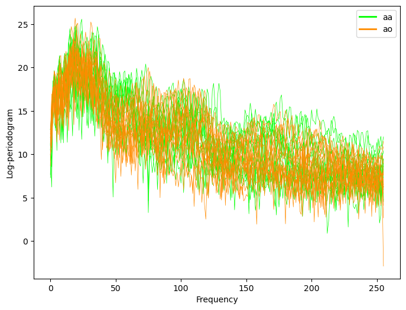

```python
import matplotlib.pyplot as plt

id0 = np.random.choice(np.where(Y == 0)[0], size=15, replace=False)
id1 = np.random.choice(np.where(Y == 1)[0], size=15, replace=False)
aa_label, ao_label = {'label': 'aa'}, {'label': 'ao'}
plt.figure(figsize=(8, 6))
plt.xlabel("Frequency")
plt.ylabel("Log-periodogram")

plt.plot([], color='#00FF00', linewidth=2, label='aa')
for i in id0:
    plt.plot(X.iloc[i], linewidth=0.5, color='#00FF00')

plt.plot([], color='#FF8C00', linewidth=2, label='ao')
for i in id1:
    plt.plot(X.iloc[i], linewidth=0.5, color='#FF8C00')

plt.legend(loc="upper right")
custom_ticks = [0, 50, 100, 150, 200, 250]
plt.xticks(custom_ticks, custom_ticks)
plt.show()
```

## Fit a Logitsic Regressio Model

$$ \log \frac{P(ao | x)}{P(aa | x)} = \beta_0 + \sum_{j=1}^{256} x_j \beta_j $$

```python
import statsmodels.api as sm
from statsmodels.tools.tools import add_constant
logfit1 = sm.GLM(Y, add_constant(X), family=sm.families.Binomial()).fit()
coef1 = logfit1.params[1:]
```

## Force the Coefficients to be Smooth

Applications such as this permit a natural regularization. The 256 measurements for each sample are not the same as measurements collected from 256 independent predictors. They are observations (at discretized frequencies) from a continuous Log-periodogram function.

Naturally we would expect the 256 coefficients $\beta_j$ are also continuous in the frequency domain. So we model it by natural cubic splines, where $h_m(v)$'s are the basis functions of natural cubic splines, defined on the set of frequencies.

$$ \beta(v) = \sum_{m=1}^M h_m(v) \theta_m, \quad v = 1, 2, \dots, 256. $$

In practice, this means $\beta_{p \times 1} = H \theta_{M \times 1}$, where $p=256$ and $H$ is a $p \times M$ with the $m$-th column being $h_m(v)$ evaluated on $v=1, 2, \dots, 256.$

$$ X_{n \times p} \color{blue}{\beta}_{p \times 1} = X_{n \times p} \color{blue}{H}_{p \times M} \color{blue}{\theta}_{M \times 1} = B_{n \times M} \color{blue}{\theta}_{M \times 1}. $$

So we can simply fit a logistic regression model with design matrix $B = X H$.

Here we used $M = 12$ basis functions, with knots uniformly placed over the integers 1,2,...,256 representing the frequencies.

```python
from scipy.interpolate import splev
def ns(x, df=None, knots=None, boundary_knots=None, include_intercept=False):
    degree = 3

    if boundary_knots is None:
        boundary_knots = [np.min(x), np.max(x)]
    else:
        boundary_knots = np.sort(boundary_knots).tolist()

    oleft = x < boundary_knots[0]
    oright = x > boundary_knots[1]
    outside = oleft | oright
    inside = ~outside

    if df is not None:
        nIknots = df - 1 - include_intercept
        if nIknots < 0:
            nIknots = 0

        if nIknots > 0:
            knots = np.linspace(0, 1, num=nIknots + 2)[1:-1]
            knots = np.quantile(x[~outside], knots)

    Aknots = np.sort(np.concatenate((boundary_knots * 4, knots)))
    n_bases = len(Aknots) - (degree + 1)

    if any(outside):
        basis = np.empty((x.shape[0], n_bases), dtype=float)
        e = 1 / 4 # in theory anything in (0, 1); was (implicitly) 0 in R <= 3.2.2

        if any(oleft):
            k_pivot = boundary_knots[0]
            xl = x[oleft] - k_pivot
            xl = np.c_[np.ones(xl.shape[0]), xl]

            # equivalent to splineDesign(Aknots, rep(k.pivot, ord), ord, derivs)
            tt = np.empty((xl.shape[1], n_bases), dtype=float)
            for j in range(xl.shape[1]):
                for i in range(n_bases):
                    coefs = np.zeros((n_bases,))
                    coefs[i] = 1
                    tt[j, i] = splev(k_pivot, (Aknots, coefs, degree), der=j)

            basis[oleft, :] = xl @ tt

        if any(oright):
            k_pivot = boundary_knots[1]
            xr = x[oright] - k_pivot
            xr = np.c_[np.ones(xr.shape[0]), xr]

            tt = np.empty((xr.shape[1], n_bases), dtype=float)
            for j in range(xr.shape[1]):
                for i in range(n_bases):
                    coefs = np.zeros((n_bases,))
                    coefs[i] = 1
                    tt[j, i] = splev(k_pivot, (Aknots, coefs, degree), der=j)

            basis[oright, :] = xr @ tt

        if any(inside):
            xi = x[inside]
            tt = np.empty((len(xi), n_bases), dtype=float)
            for i in range(n_bases):
                coefs = np.zeros((n_bases,))
                coefs[i] = 1
                tt[:, i] = splev(xi, (Aknots, coefs, degree))

            basis[inside, :] = tt
    else:
        basis = np.empty((x.shape[0], n_bases), dtype=float)
        for i in range(n_bases):
            coefs = np.zeros((n_bases,))
            coefs[i] = 1
            basis[:, i] = splev(x, (Aknots, coefs, degree))

    const = np.empty((2, n_bases), dtype=float)
    for i in range(n_bases):
        coefs = np.zeros((n_bases,))
        coefs[i] = 1
        const[:, i] = splev(boundary_knots, (Aknots, coefs, degree), der=2)

    if include_intercept is False:
        basis = basis[:, 1:]
        const = const[:, 1:]

    qr_const = np.linalg.qr(const.T, mode='complete')[0]
    basis = (qr_const.T @ basis.T).T[:, 2:]

    return basis
```

```python
H = ns(np.arange(1, 257), df = 12)
B = X @ H
logfit2 = sm.GLM(Y, add_constant(B), family=sm.families.Binomial()).fit()
coef2 = H @ logfit2.params.to_numpy()[1:]
```

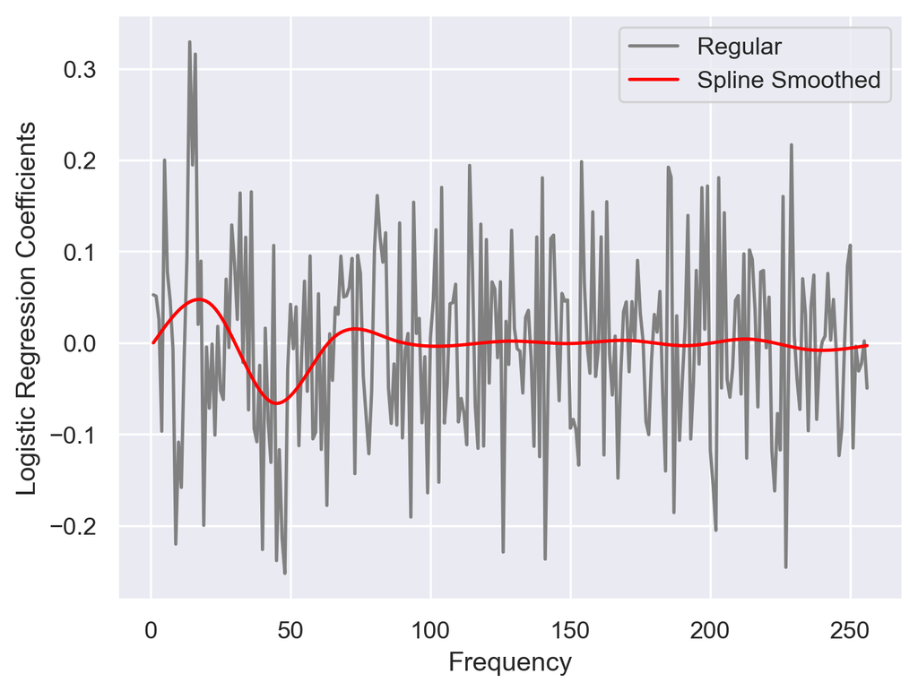

```python
import matplotlib.pyplot as plt
import matplotlib as mpl
import seaborn as sns
mpl.rcParams['figure.dpi'] = 250
sns.set()
plt.plot(np.arange(1,257), coef1, color = 'gray', label = 'Regular');
plt.plot(np.arange(1,257), coef2, color = 'red', label = 'Spline Smoothed');
plt.legend();
plt.xlabel("Frequency");
plt.ylabel("Logistic Regression Coefficients");
```

## Compare Classification Performance

Next we conduct a simulation study to evaluate the classification accuracy of the two models:

- M1: A logistic regression model with 256 regression coefficients
- M2: A logistic regression model that models the 256 coefficients using a NCS with 12 dfs.

```python
T = 5
n = len(X)
Err1 = np.zeros((T,2))
Err2 = np.zeros((T,2))
np.random.seed(0)
for t in range(T):
  mask = np.in1d(np.arange(n), np.random.choice(n, int(n*0.2)))
  logfit1 = sm.GLM(Y[~mask], add_constant(X)[~mask], family = sm.families.Binomial()).fit()
  yhat1 = (logfit1.fittedvalues > 0.5).astype(float)
  Err1[t, 0] = (yhat1 != Y[~mask]).mean()
  yhat1 = (add_constant(X)[mask] @ logfit1.params > 0.5).astype(float)
  Err1[t, 1] = (yhat1 != Y[mask]).mean()

  logfit2 = sm.GLM(Y[~mask], add_constant(B)[~mask], family = sm.families.Binomial()).fit()
  yhat2 = (logfit2.fittedvalues > 0.5).astype(float)
  Err2[t, 0] = (yhat2 != Y[~mask]).mean()
  yhat2 = (add_constant(B)[mask] @ logfit2.params > 0.5).astype(float)
  Err2[t, 1] = (yhat2 != Y[mask]).mean()

pd.DataFrame(np.hstack([Err1, Err2]), columns = ['Regular Train Error', 'Regular Test Error',
                                                 'Spline Train Error', 'Spline Test Error'])
```

|  | Regular Train Error | Regular Test Error | Spline Train Error | Spline Test Error |
| --- | --- | --- | --- | --- |
| 0 | 0.101068 | 0.256410 | 0.168683 | 0.211538 |
| 1 | 0.110163 | 0.254839 | 0.180526 | 0.174194 |
| 2 | 0.120397 | 0.249180 | 0.178470 | 0.186885 |
| 3 | 0.114731 | 0.186885 | 0.177054 | 0.177049 |
| 4 | 0.100000 | 0.250814 | 0.176596 | 0.182410 |

- M1 exhibits lower training errors, primarily due to its higher number of regression coefficients.
- However, when it comes to the test error, M2 surpasses M1, indicating that the former model delivers better performance on unseen data.